# Risk Factor Analysis

## Outcome Variable

**Outcome Variable:** sstunted

## Predictor Variables

**Intervention Variable:** fage

**Adjustment Set:**

unadjusted

## Stratifying Variables

The analysis was stratified on these variable(s):

- agecat
- studyid
- country

## Data Summary

| agecat | studyid | country | A | n | nA | nAY0 | nAY1 |
| --- | --- | --- | --- | --- | --- | --- | --- |
| Birth | ki0047075b-MAL-ED | BANGLADESH | >=35 | 145 | 99 | 98 | 1 |
| Birth | ki0047075b-MAL-ED | BANGLADESH | <25 | 145 | 0 | 0 | 0 |
| Birth | ki0047075b-MAL-ED | BANGLADESH | [25-30) | 145 | 13 | 12 | 1 |
| Birth | ki0047075b-MAL-ED | BANGLADESH | [30-35) | 145 | 33 | 32 | 1 |
| Birth | ki0047075b-MAL-ED | BRAZIL | >=35 | 68 | 35 | 33 | 2 |
| Birth | ki0047075b-MAL-ED | BRAZIL | <25 | 68 | 3 | 3 | 0 |
| Birth | ki0047075b-MAL-ED | BRAZIL | [25-30) | 68 | 7 | 7 | 0 |
| Birth | ki0047075b-MAL-ED | BRAZIL | [30-35) | 68 | 23 | 22 | 1 |
| Birth | ki0047075b-MAL-ED | INDIA | >=35 | 131 | 57 | 55 | 2 |
| Birth | ki0047075b-MAL-ED | INDIA | <25 | 131 | 2 | 2 | 0 |
| Birth | ki0047075b-MAL-ED | INDIA | [25-30) | 131 | 24 | 23 | 1 |
| Birth | ki0047075b-MAL-ED | INDIA | [30-35) | 131 | 48 | 47 | 1 |
| Birth | ki0047075b-MAL-ED | NEPAL | >=35 | 61 | 31 | 31 | 0 |
| Birth | ki0047075b-MAL-ED | NEPAL | <25 | 61 | 0 | 0 | 0 |
| Birth | ki0047075b-MAL-ED | NEPAL | [25-30) | 61 | 6 | 6 | 0 |
| Birth | ki0047075b-MAL-ED | NEPAL | [30-35) | 61 | 24 | 22 | 2 |
| Birth | ki0047075b-MAL-ED | PERU | >=35 | 80 | 42 | 42 | 0 |
| Birth | ki0047075b-MAL-ED | PERU | <25 | 80 | 4 | 4 | 0 |
| Birth | ki0047075b-MAL-ED | PERU | [25-30) | 80 | 17 | 17 | 0 |
| Birth | ki0047075b-MAL-ED | PERU | [30-35) | 80 | 17 | 17 | 0 |
| Birth | ki0047075b-MAL-ED | SOUTH AFRICA | >=35 | 76 | 63 | 62 | 1 |
| Birth | ki0047075b-MAL-ED | SOUTH AFRICA | <25 | 76 | 1 | 1 | 0 |
| Birth | ki0047075b-MAL-ED | SOUTH AFRICA | [25-30) | 76 | 5 | 5 | 0 |
| Birth | ki0047075b-MAL-ED | SOUTH AFRICA | [30-35) | 76 | 7 | 7 | 0 |
| Birth | ki0047075b-MAL-ED | TANZANIA, UNITED REPUBLIC OF | >=35 | 46 | 27 | 26 | 1 |
| Birth | ki0047075b-MAL-ED | TANZANIA, UNITED REPUBLIC OF | <25 | 46 | 1 | 1 | 0 |
| Birth | ki0047075b-MAL-ED | TANZANIA, UNITED REPUBLIC OF | [25-30) | 46 | 3 | 3 | 0 |
| Birth | ki0047075b-MAL-ED | TANZANIA, UNITED REPUBLIC OF | [30-35) | 46 | 15 | 14 | 1 |
| Birth | ki1000304b-SAS-CompFeed | INDIA | >=35 | 70 | 5 | 5 | 0 |
| Birth | ki1000304b-SAS-CompFeed | INDIA | <25 | 70 | 23 | 21 | 2 |

[output cut: 314 more lines]

The following strata were considered:

- agecat: 12 months, studyid: ki0047075b-MAL-ED, country: BANGLADESH
- agecat: 12 months, studyid: ki0047075b-MAL-ED, country: BRAZIL
- agecat: 12 months, studyid: ki0047075b-MAL-ED, country: INDIA
- agecat: 12 months, studyid: ki0047075b-MAL-ED, country: NEPAL
- agecat: 12 months, studyid: ki0047075b-MAL-ED, country: PERU
- agecat: 12 months, studyid: ki0047075b-MAL-ED, country: SOUTH AFRICA
- agecat: 12 months, studyid: ki0047075b-MAL-ED, country: TANZANIA, UNITED REPUBLIC OF
- agecat: 12 months, studyid: ki1000304b-SAS-CompFeed, country: INDIA
- agecat: 12 months, studyid: ki1000304b-SAS-FoodSuppl, country: INDIA
- agecat: 12 months, studyid: ki1119695-PROBIT, country: BELARUS
- agecat: 12 months, studyid: ki1135781-COHORTS, country: GUATEMALA
- agecat: 12 months, studyid: ki1135781-COHORTS, country: PHILIPPINES
- agecat: 12 months, studyid: ki1148112-LCNI-5, country: MALAWI
- agecat: 18 months, studyid: ki0047075b-MAL-ED, country: BANGLADESH
- agecat: 18 months, studyid: ki0047075b-MAL-ED, country: BRAZIL
- agecat: 18 months, studyid: ki0047075b-MAL-ED, country: INDIA
- agecat: 18 months, studyid: ki0047075b-MAL-ED, country: NEPAL
- agecat: 18 months, studyid: ki0047075b-MAL-ED, country: PERU
- agecat: 18 months, studyid: ki0047075b-MAL-ED, country: SOUTH AFRICA
- agecat: 18 months, studyid: ki0047075b-MAL-ED, country: TANZANIA, UNITED REPUBLIC OF
- agecat: 18 months, studyid: ki1000304b-SAS-CompFeed, country: INDIA
- agecat: 18 months, studyid: ki1000304b-SAS-FoodSuppl, country: INDIA
- agecat: 18 months, studyid: ki1119695-PROBIT, country: BELARUS
- agecat: 18 months, studyid: ki1135781-COHORTS, country: GUATEMALA
- agecat: 18 months, studyid: ki1135781-COHORTS, country: PHILIPPINES
- agecat: 18 months, studyid: ki1148112-LCNI-5, country: MALAWI
- agecat: 24 months, studyid: ki0047075b-MAL-ED, country: BANGLADESH
- agecat: 24 months, studyid: ki0047075b-MAL-ED, country: BRAZIL
- agecat: 24 months, studyid: ki0047075b-MAL-ED, country: INDIA
- agecat: 24 months, studyid: ki0047075b-MAL-ED, country: NEPAL
- agecat: 24 months, studyid: ki0047075b-MAL-ED, country: PERU
- agecat: 24 months, studyid: ki0047075b-MAL-ED, country: SOUTH AFRICA
- agecat: 24 months, studyid: ki0047075b-MAL-ED, country: TANZANIA, UNITED REPUBLIC OF
- agecat: 24 months, studyid: ki1119695-PROBIT, country: BELARUS
- agecat: 24 months, studyid: ki1135781-COHORTS, country: GUATEMALA
- agecat: 24 months, studyid: ki1135781-COHORTS, country: PHILIPPINES
- agecat: 24 months, studyid: ki1148112-LCNI-5, country: MALAWI
- agecat: 3 months, studyid: ki0047075b-MAL-ED, country: BANGLADESH
- agecat: 3 months, studyid: ki0047075b-MAL-ED, country: BRAZIL
- agecat: 3 months, studyid: ki0047075b-MAL-ED, country: INDIA
- agecat: 3 months, studyid: ki0047075b-MAL-ED, country: NEPAL
- agecat: 3 months, studyid: ki0047075b-MAL-ED, country: PERU
- agecat: 3 months, studyid: ki0047075b-MAL-ED, country: SOUTH AFRICA
- agecat: 3 months, studyid: ki0047075b-MAL-ED, country: TANZANIA, UNITED REPUBLIC OF
- agecat: 3 months, studyid: ki1000304b-SAS-CompFeed, country: INDIA
- agecat: 3 months, studyid: ki1000304b-SAS-FoodSuppl, country: INDIA
- agecat: 3 months, studyid: ki1119695-PROBIT, country: BELARUS
- agecat: 3 months, studyid: ki1135781-COHORTS, country: GUATEMALA
- agecat: 3 months, studyid: ki1135781-COHORTS, country: PHILIPPINES
- agecat: 6 months, studyid: ki0047075b-MAL-ED, country: BANGLADESH
- agecat: 6 months, studyid: ki0047075b-MAL-ED, country: BRAZIL
- agecat: 6 months, studyid: ki0047075b-MAL-ED, country: INDIA
- agecat: 6 months, studyid: ki0047075b-MAL-ED, country: NEPAL
- agecat: 6 months, studyid: ki0047075b-MAL-ED, country: PERU
- agecat: 6 months, studyid: ki0047075b-MAL-ED, country: SOUTH AFRICA
- agecat: 6 months, studyid: ki0047075b-MAL-ED, country: TANZANIA, UNITED REPUBLIC OF
- agecat: 6 months, studyid: ki1000304b-SAS-CompFeed, country: INDIA
- agecat: 6 months, studyid: ki1000304b-SAS-FoodSuppl, country: INDIA
- agecat: 6 months, studyid: ki1119695-PROBIT, country: BELARUS
- agecat: 6 months, studyid: ki1135781-COHORTS, country: GUATEMALA
- agecat: 6 months, studyid: ki1135781-COHORTS, country: PHILIPPINES
- agecat: 6 months, studyid: ki1148112-LCNI-5, country: MALAWI
- agecat: 9 months, studyid: ki0047075b-MAL-ED, country: BANGLADESH
- agecat: 9 months, studyid: ki0047075b-MAL-ED, country: BRAZIL
- agecat: 9 months, studyid: ki0047075b-MAL-ED, country: INDIA
- agecat: 9 months, studyid: ki0047075b-MAL-ED, country: NEPAL
- agecat: 9 months, studyid: ki0047075b-MAL-ED, country: PERU
- agecat: 9 months, studyid: ki0047075b-MAL-ED, country: SOUTH AFRICA
- agecat: 9 months, studyid: ki0047075b-MAL-ED, country: TANZANIA, UNITED REPUBLIC OF
- agecat: 9 months, studyid: ki1000304b-SAS-CompFeed, country: INDIA
- agecat: 9 months, studyid: ki1000304b-SAS-FoodSuppl, country: INDIA
- agecat: 9 months, studyid: ki1119695-PROBIT, country: BELARUS
- agecat: 9 months, studyid: ki1135781-COHORTS, country: GUATEMALA
- agecat: 9 months, studyid: ki1135781-COHORTS, country: PHILIPPINES
- agecat: 9 months, studyid: ki1148112-LCNI-5, country: MALAWI
- agecat: Birth, studyid: ki0047075b-MAL-ED, country: BANGLADESH
- agecat: Birth, studyid: ki0047075b-MAL-ED, country: BRAZIL
- agecat: Birth, studyid: ki0047075b-MAL-ED, country: INDIA
- agecat: Birth, studyid: ki0047075b-MAL-ED, country: NEPAL
- agecat: Birth, studyid: ki0047075b-MAL-ED, country: PERU
- agecat: Birth, studyid: ki0047075b-MAL-ED, country: SOUTH AFRICA
- agecat: Birth, studyid: ki0047075b-MAL-ED, country: TANZANIA, UNITED REPUBLIC OF
- agecat: Birth, studyid: ki1000304b-SAS-CompFeed, country: INDIA
- agecat: Birth, studyid: ki1119695-PROBIT, country: BELARUS
- agecat: Birth, studyid: ki1135781-COHORTS, country: GUATEMALA
- agecat: Birth, studyid: ki1135781-COHORTS, country: PHILIPPINES

### Dropped Strata

Some strata were dropped due to rare outcomes:

- agecat: Birth, studyid: ki0047075b-MAL-ED, country: BANGLADESH
- agecat: Birth, studyid: ki0047075b-MAL-ED, country: BRAZIL
- agecat: Birth, studyid: ki0047075b-MAL-ED, country: INDIA
- agecat: Birth, studyid: ki0047075b-MAL-ED, country: NEPAL
- agecat: Birth, studyid: ki0047075b-MAL-ED, country: PERU
- agecat: Birth, studyid: ki0047075b-MAL-ED, country: SOUTH AFRICA
- agecat: Birth, studyid: ki0047075b-MAL-ED, country: TANZANIA, UNITED REPUBLIC OF
- agecat: Birth, studyid: ki1000304b-SAS-CompFeed, country: INDIA
- agecat: Birth, studyid: ki1119695-PROBIT, country: BELARUS
- agecat: Birth, studyid: ki1135781-COHORTS, country: GUATEMALA
- agecat: 3 months, studyid: ki0047075b-MAL-ED, country: BANGLADESH
- agecat: 3 months, studyid: ki0047075b-MAL-ED, country: BRAZIL
- agecat: 3 months, studyid: ki0047075b-MAL-ED, country: INDIA
- agecat: 3 months, studyid: ki0047075b-MAL-ED, country: NEPAL
- agecat: 3 months, studyid: ki0047075b-MAL-ED, country: PERU
- agecat: 3 months, studyid: ki0047075b-MAL-ED, country: SOUTH AFRICA
- agecat: 3 months, studyid: ki0047075b-MAL-ED, country: TANZANIA, UNITED REPUBLIC OF
- agecat: 3 months, studyid: ki1000304b-SAS-CompFeed, country: INDIA
- agecat: 3 months, studyid: ki1000304b-SAS-FoodSuppl, country: INDIA
- agecat: 3 months, studyid: ki1135781-COHORTS, country: GUATEMALA
- agecat: 6 months, studyid: ki0047075b-MAL-ED, country: BANGLADESH
- agecat: 6 months, studyid: ki0047075b-MAL-ED, country: BRAZIL
- agecat: 6 months, studyid: ki0047075b-MAL-ED, country: INDIA
- agecat: 6 months, studyid: ki0047075b-MAL-ED, country: NEPAL
- agecat: 6 months, studyid: ki0047075b-MAL-ED, country: PERU
- agecat: 6 months, studyid: ki0047075b-MAL-ED, country: SOUTH AFRICA
- agecat: 6 months, studyid: ki0047075b-MAL-ED, country: TANZANIA, UNITED REPUBLIC OF
- agecat: 6 months, studyid: ki1000304b-SAS-FoodSuppl, country: INDIA
- agecat: 6 months, studyid: ki1148112-LCNI-5, country: MALAWI
- agecat: 9 months, studyid: ki0047075b-MAL-ED, country: BANGLADESH
- agecat: 9 months, studyid: ki0047075b-MAL-ED, country: BRAZIL
- agecat: 9 months, studyid: ki0047075b-MAL-ED, country: INDIA
- agecat: 9 months, studyid: ki0047075b-MAL-ED, country: NEPAL
- agecat: 9 months, studyid: ki0047075b-MAL-ED, country: PERU
- agecat: 9 months, studyid: ki0047075b-MAL-ED, country: SOUTH AFRICA
- agecat: 9 months, studyid: ki0047075b-MAL-ED, country: TANZANIA, UNITED REPUBLIC OF
- agecat: 9 months, studyid: ki1000304b-SAS-FoodSuppl, country: INDIA
- agecat: 9 months, studyid: ki1148112-LCNI-5, country: MALAWI
- agecat: 12 months, studyid: ki0047075b-MAL-ED, country: BANGLADESH
- agecat: 12 months, studyid: ki0047075b-MAL-ED, country: BRAZIL
- agecat: 12 months, studyid: ki0047075b-MAL-ED, country: INDIA
- agecat: 12 months, studyid: ki0047075b-MAL-ED, country: NEPAL
- agecat: 12 months, studyid: ki0047075b-MAL-ED, country: PERU
- agecat: 12 months, studyid: ki0047075b-MAL-ED, country: SOUTH AFRICA
- agecat: 12 months, studyid: ki0047075b-MAL-ED, country: TANZANIA, UNITED REPUBLIC OF
- agecat: 12 months, studyid: ki1119695-PROBIT, country: BELARUS
- agecat: 12 months, studyid: ki1148112-LCNI-5, country: MALAWI
- agecat: 18 months, studyid: ki0047075b-MAL-ED, country: BANGLADESH
- agecat: 18 months, studyid: ki0047075b-MAL-ED, country: BRAZIL
- agecat: 18 months, studyid: ki0047075b-MAL-ED, country: INDIA
- agecat: 18 months, studyid: ki0047075b-MAL-ED, country: NEPAL
- agecat: 18 months, studyid: ki0047075b-MAL-ED, country: PERU
- agecat: 18 months, studyid: ki0047075b-MAL-ED, country: SOUTH AFRICA
- agecat: 18 months, studyid: ki0047075b-MAL-ED, country: TANZANIA, UNITED REPUBLIC OF
- agecat: 18 months, studyid: ki1119695-PROBIT, country: BELARUS
- agecat: 18 months, studyid: ki1148112-LCNI-5, country: MALAWI
- agecat: 24 months, studyid: ki0047075b-MAL-ED, country: BANGLADESH
- agecat: 24 months, studyid: ki0047075b-MAL-ED, country: BRAZIL
- agecat: 24 months, studyid: ki0047075b-MAL-ED, country: INDIA
- agecat: 24 months, studyid: ki0047075b-MAL-ED, country: NEPAL
- agecat: 24 months, studyid: ki0047075b-MAL-ED, country: PERU
- agecat: 24 months, studyid: ki0047075b-MAL-ED, country: SOUTH AFRICA
- agecat: 24 months, studyid: ki0047075b-MAL-ED, country: TANZANIA, UNITED REPUBLIC OF
- agecat: 24 months, studyid: ki1119695-PROBIT, country: BELARUS
- agecat: 24 months, studyid: ki1148112-LCNI-5, country: MALAWI

## Methods Detail

We’re interested in the causal parameters $E[Y_a]$ for all values of $a \in \mathcal{A}$. These parameters represent the mean outcome if, possibly contrary to fact, we intervened to set all units to have $A=a$. Under the randomization and positivity assumptions, these are identified by the statistical parameters $\psi_a=E_W[E_{Y|A,W}(Y|A=a,W)]$. In addition, we’re interested in the mean of $Y$, $E[Y]$ under no intervention (the observed mean). We will estimate these parameters by using SuperLearner to fit the relevant likelihood factors – $E_{Y|A,W}(Y|A=a,W)$ and $p(A=a|W)$, and then updating our likelihood fit using a joint TMLE.

For unadjusted analyses ($W=\{\}$), initial likelihoods were estimated using Lrnr_glm to estimate the simple $E(Y|A)$ and Lrnr_mean to estimate $p(A)$. For adjusted analyses, a small library containing Lrnr_glmnet, Lrnr_xgboost, and Lrnr_mean was used.

Having estimated these parameters, we will then use the delta method to estimate relative risks and attributable risks relative to a prespecified baseline level of $A$.

# Results Detail

## Results Plots

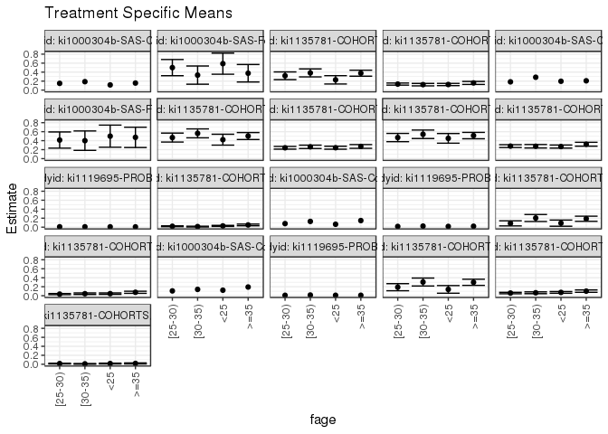

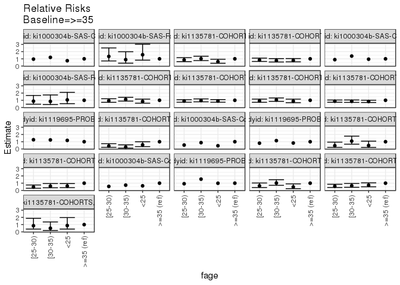

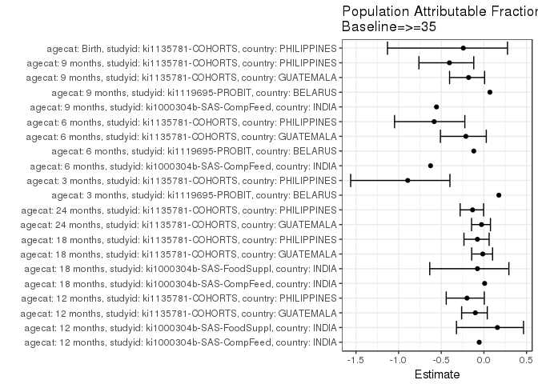

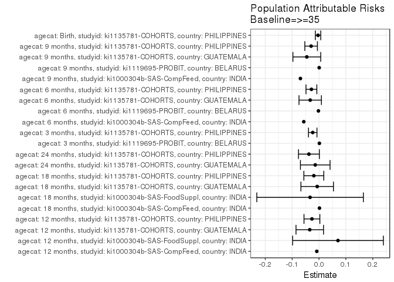

## Results Table

### Parameter: TSM

| agecat | studyid | country | intervention_level | baseline_level | estimate | ci_lower | ci_upper |
| --- | --- | --- | --- | --- | --- | --- | --- |
| Birth | ki1135781-COHORTS | PHILIPPINES | >=35 | NA | 0.0185529 | 0.0071591 | 0.0299466 |
| Birth | ki1135781-COHORTS | PHILIPPINES | <25 | NA | 0.0161692 | 0.0074495 | 0.0248888 |
| Birth | ki1135781-COHORTS | PHILIPPINES | [25-30) | NA | 0.0157233 | 0.0078278 | 0.0236187 |
| Birth | ki1135781-COHORTS | PHILIPPINES | [30-35) | NA | 0.0092736 | 0.0018865 | 0.0166606 |
| 3 months | ki1119695-PROBIT | BELARUS | >=35 | NA | 0.0064935 | NA | NA |
| 3 months | ki1119695-PROBIT | BELARUS | <25 | NA | 0.0076923 | NA | NA |
| 3 months | ki1119695-PROBIT | BELARUS | [25-30) | NA | 0.0082844 | NA | NA |
| 3 months | ki1119695-PROBIT | BELARUS | [30-35) | NA | 0.0081136 | NA | NA |
| 3 months | ki1135781-COHORTS | PHILIPPINES | >=35 | NA | 0.0496183 | 0.0310219 | 0.0682148 |
| 3 months | ki1135781-COHORTS | PHILIPPINES | <25 | NA | 0.0281501 | 0.0162789 | 0.0400214 |
| 3 months | ki1135781-COHORTS | PHILIPPINES | [25-30) | NA | 0.0200893 | 0.0109007 | 0.0292778 |
| 3 months | ki1135781-COHORTS | PHILIPPINES | [30-35) | NA | 0.0129241 | 0.0040248 | 0.0218234 |
| 6 months | ki1000304b-SAS-CompFeed | INDIA | >=35 | NA | 0.1470588 | NA | NA |
| 6 months | ki1000304b-SAS-CompFeed | INDIA | <25 | NA | 0.0648148 | NA | NA |
| 6 months | ki1000304b-SAS-CompFeed | INDIA | [25-30) | NA | 0.0793651 | NA | NA |
| 6 months | ki1000304b-SAS-CompFeed | INDIA | [30-35) | NA | 0.1282051 | NA | NA |
| 6 months | ki1119695-PROBIT | BELARUS | >=35 | NA | 0.0203528 | NA | NA |
| 6 months | ki1119695-PROBIT | BELARUS | <25 | NA | 0.0167415 | NA | NA |
| 6 months | ki1119695-PROBIT | BELARUS | [25-30) | NA | 0.0162396 | NA | NA |
| 6 months | ki1119695-PROBIT | BELARUS | [30-35) | NA | 0.0234375 | NA | NA |
| 6 months | ki1135781-COHORTS | GUATEMALA | >=35 | NA | 0.1878453 | 0.1308792 | 0.2448115 |
| 6 months | ki1135781-COHORTS | GUATEMALA | <25 | NA | 0.0895522 | 0.0211036 | 0.1580009 |
| 6 months | ki1135781-COHORTS | GUATEMALA | [25-30) | NA | 0.0851064 | 0.0286336 | 0.1415791 |
| 6 months | ki1135781-COHORTS | GUATEMALA | [30-35) | NA | 0.2038835 | 0.1259907 | 0.2817763 |
| 6 months | ki1135781-COHORTS | PHILIPPINES | >=35 | NA | 0.0766129 | 0.0532012 | 0.1000246 |
| 6 months | ki1135781-COHORTS | PHILIPPINES | <25 | NA | 0.0462185 | 0.0308152 | 0.0616218 |
| 6 months | ki1135781-COHORTS | PHILIPPINES | [25-30) | NA | 0.0359712 | 0.0233305 | 0.0486119 |
| 6 months | ki1135781-COHORTS | PHILIPPINES | [30-35) | NA | 0.0448276 | 0.0279842 | 0.0616710 |
| 9 months | ki1000304b-SAS-CompFeed | INDIA | >=35 | NA | 0.1935484 | NA | NA |
| 9 months | ki1000304b-SAS-CompFeed | INDIA | <25 | NA | 0.1226415 | NA | NA |

[output cut: 54 more lines]

### Parameter: E(Y)

| agecat | studyid | country | intervention_level | baseline_level | estimate | ci_lower | ci_upper |
| --- | --- | --- | --- | --- | --- | --- | --- |
| Birth | ki1135781-COHORTS | PHILIPPINES | NA | NA | 0.0149457 | 0.0105620 | 0.0193293 |
| 3 months | ki1119695-PROBIT | BELARUS | NA | NA | 0.0078750 | NA | NA |
| 3 months | ki1135781-COHORTS | PHILIPPINES | NA | NA | 0.0262118 | 0.0202772 | 0.0321465 |
| 6 months | ki1000304b-SAS-CompFeed | INDIA | NA | NA | 0.0904645 | NA | NA |
| 6 months | ki1119695-PROBIT | BELARUS | NA | NA | 0.0181942 | NA | NA |
| 6 months | ki1135781-COHORTS | GUATEMALA | NA | NA | 0.1550562 | 0.1213884 | 0.1887240 |
| 6 months | ki1135781-COHORTS | PHILIPPINES | NA | NA | 0.0483994 | 0.0401865 | 0.0566123 |
| 9 months | ki1000304b-SAS-CompFeed | INDIA | NA | NA | 0.1243781 | NA | NA |
| 9 months | ki1119695-PROBIT | BELARUS | NA | NA | 0.0104123 | NA | NA |
| 9 months | ki1135781-COHORTS | GUATEMALA | NA | NA | 0.2528736 | 0.2119803 | 0.2937668 |
| 9 months | ki1135781-COHORTS | PHILIPPINES | NA | NA | 0.0726788 | 0.0627514 | 0.0826063 |
| 12 months | ki1000304b-SAS-CompFeed | INDIA | NA | NA | 0.1480583 | NA | NA |
| 12 months | ki1000304b-SAS-FoodSuppl | INDIA | NA | NA | 0.4456522 | 0.3435308 | 0.5477735 |
| 12 months | ki1135781-COHORTS | GUATEMALA | NA | NA | 0.3418468 | 0.3005995 | 0.3830941 |
| 12 months | ki1135781-COHORTS | PHILIPPINES | NA | NA | 0.1328281 | 0.1195402 | 0.1461159 |
| 18 months | ki1000304b-SAS-CompFeed | INDIA | NA | NA | 0.2086514 | NA | NA |
| 18 months | ki1000304b-SAS-FoodSuppl | INDIA | NA | NA | 0.4404762 | 0.3336742 | 0.5472782 |
| 18 months | ki1135781-COHORTS | GUATEMALA | NA | NA | 0.4964029 | 0.4483566 | 0.5444492 |
| 18 months | ki1135781-COHORTS | PHILIPPINES | NA | NA | 0.2520695 | 0.2347522 | 0.2693868 |
| 24 months | ki1135781-COHORTS | GUATEMALA | NA | NA | 0.4989899 | 0.4548985 | 0.5430813 |
| 24 months | ki1135781-COHORTS | PHILIPPINES | NA | NA | 0.2830030 | 0.2648675 | 0.3011384 |

### Parameter: RR

| agecat | studyid | country | intervention_level | baseline_level | estimate | ci_lower | ci_upper |
| --- | --- | --- | --- | --- | --- | --- | --- |
| Birth | ki1135781-COHORTS | PHILIPPINES | >=35 | >=35 | 1.0000000 | 1.0000000 | 1.0000000 |
| Birth | ki1135781-COHORTS | PHILIPPINES | <25 | >=35 | 0.8715174 | 0.3848851 | 1.9734270 |
| Birth | ki1135781-COHORTS | PHILIPPINES | [25-30) | >=35 | 0.8474843 | 0.3833644 | 1.8734906 |
| Birth | ki1135781-COHORTS | PHILIPPINES | [30-35) | >=35 | 0.4998454 | 0.1828163 | 1.3666478 |
| 3 months | ki1119695-PROBIT | BELARUS | >=35 | >=35 | 1.0000000 | NA | NA |
| 3 months | ki1119695-PROBIT | BELARUS | <25 | >=35 | 1.1846153 | NA | NA |
| 3 months | ki1119695-PROBIT | BELARUS | [25-30) | >=35 | 1.2758025 | NA | NA |
| 3 months | ki1119695-PROBIT | BELARUS | [30-35) | >=35 | 1.2494928 | NA | NA |
| 3 months | ki1135781-COHORTS | PHILIPPINES | >=35 | >=35 | 1.0000000 | 1.0000000 | 1.0000000 |
| 3 months | ki1135781-COHORTS | PHILIPPINES | <25 | >=35 | 0.5673335 | 0.3227114 | 0.9973841 |
| 3 months | ki1135781-COHORTS | PHILIPPINES | [25-30) | >=35 | 0.4048764 | 0.2241359 | 0.7313636 |
| 3 months | ki1135781-COHORTS | PHILIPPINES | [30-35) | >=35 | 0.2604697 | 0.1189274 | 0.5704698 |
| 6 months | ki1000304b-SAS-CompFeed | INDIA | >=35 | >=35 | 1.0000000 | NA | NA |
| 6 months | ki1000304b-SAS-CompFeed | INDIA | <25 | >=35 | 0.4407407 | NA | NA |
| 6 months | ki1000304b-SAS-CompFeed | INDIA | [25-30) | >=35 | 0.5396825 | NA | NA |
| 6 months | ki1000304b-SAS-CompFeed | INDIA | [30-35) | >=35 | 0.8717949 | NA | NA |
| 6 months | ki1119695-PROBIT | BELARUS | >=35 | >=35 | 1.0000000 | NA | NA |
| 6 months | ki1119695-PROBIT | BELARUS | <25 | >=35 | 0.8225670 | NA | NA |
| 6 months | ki1119695-PROBIT | BELARUS | [25-30) | >=35 | 0.7979069 | NA | NA |
| 6 months | ki1119695-PROBIT | BELARUS | [30-35) | >=35 | 1.1515625 | NA | NA |
| 6 months | ki1135781-COHORTS | GUATEMALA | >=35 | >=35 | 1.0000000 | 1.0000000 | 1.0000000 |
| 6 months | ki1135781-COHORTS | GUATEMALA | <25 | >=35 | 0.4767340 | 0.2094850 | 1.0849239 |
| 6 months | ki1135781-COHORTS | GUATEMALA | [25-30) | >=35 | 0.4530663 | 0.2184306 | 0.9397450 |
| 6 months | ki1135781-COHORTS | GUATEMALA | [30-35) | >=35 | 1.0853798 | 0.6664123 | 1.7677484 |
| 6 months | ki1135781-COHORTS | PHILIPPINES | >=35 | >=35 | 1.0000000 | 1.0000000 | 1.0000000 |
| 6 months | ki1135781-COHORTS | PHILIPPINES | <25 | >=35 | 0.6032729 | 0.3838325 | 0.9481692 |
| 6 months | ki1135781-COHORTS | PHILIPPINES | [25-30) | >=35 | 0.4695191 | 0.2947167 | 0.7480004 |
| 6 months | ki1135781-COHORTS | PHILIPPINES | [30-35) | >=35 | 0.5851180 | 0.3605025 | 0.9496830 |
| 9 months | ki1000304b-SAS-CompFeed | INDIA | >=35 | >=35 | 1.0000000 | NA | NA |
| 9 months | ki1000304b-SAS-CompFeed | INDIA | <25 | >=35 | 0.6336478 | NA | NA |

[output cut: 54 more lines]

### Parameter: PAR

| agecat | studyid | country | intervention_level | baseline_level | estimate | ci_lower | ci_upper |
| --- | --- | --- | --- | --- | --- | --- | --- |
| Birth | ki1135781-COHORTS | PHILIPPINES | >=35 | NA | -0.0036072 | -0.0136819 | 0.0064675 |
| 3 months | ki1119695-PROBIT | BELARUS | >=35 | NA | 0.0013815 | NA | NA |
| 3 months | ki1135781-COHORTS | PHILIPPINES | >=35 | NA | -0.0234065 | -0.0392467 | -0.0075662 |
| 6 months | ki1000304b-SAS-CompFeed | INDIA | >=35 | NA | -0.0565943 | NA | NA |
| 6 months | ki1119695-PROBIT | BELARUS | >=35 | NA | -0.0021586 | NA | NA |
| 6 months | ki1135781-COHORTS | GUATEMALA | >=35 | NA | -0.0327891 | -0.0744880 | 0.0089098 |
| 6 months | ki1135781-COHORTS | PHILIPPINES | >=35 | NA | -0.0282135 | -0.0484211 | -0.0080059 |
| 9 months | ki1000304b-SAS-CompFeed | INDIA | >=35 | NA | -0.0691703 | NA | NA |
| 9 months | ki1119695-PROBIT | BELARUS | >=35 | NA | 0.0007304 | NA | NA |
| 9 months | ki1135781-COHORTS | GUATEMALA | >=35 | NA | -0.0453721 | -0.0971386 | 0.0063945 |
| 9 months | ki1135781-COHORTS | PHILIPPINES | >=35 | NA | -0.0293620 | -0.0527968 | -0.0059271 |
| 12 months | ki1000304b-SAS-CompFeed | INDIA | >=35 | NA | -0.0081917 | NA | NA |
| 12 months | ki1000304b-SAS-FoodSuppl | INDIA | >=35 | NA | 0.0706522 | -0.0983671 | 0.2396715 |
| 12 months | ki1135781-COHORTS | GUATEMALA | >=35 | NA | -0.0343909 | -0.0856140 | 0.0168323 |
| 12 months | ki1135781-COHORTS | PHILIPPINES | >=35 | NA | -0.0263117 | -0.0558452 | 0.0032218 |
| 18 months | ki1000304b-SAS-CompFeed | INDIA | >=35 | NA | 0.0017548 | NA | NA |
| 18 months | ki1000304b-SAS-FoodSuppl | INDIA | >=35 | NA | -0.0332080 | -0.2315568 | 0.1651408 |
| 18 months | ki1135781-COHORTS | GUATEMALA | >=35 | NA | -0.0067027 | -0.0672882 | 0.0538827 |
| 18 months | ki1135781-COHORTS | PHILIPPINES | >=35 | NA | -0.0192309 | -0.0563044 | 0.0178426 |
| 24 months | ki1135781-COHORTS | GUATEMALA | >=35 | NA | -0.0139635 | -0.0691110 | 0.0411841 |
| 24 months | ki1135781-COHORTS | PHILIPPINES | >=35 | NA | -0.0375388 | -0.0764266 | 0.0013489 |

### Parameter: PAF

| agecat | studyid | country | intervention_level | baseline_level | estimate | ci_lower | ci_upper |
| --- | --- | --- | --- | --- | --- | --- | --- |
| Birth | ki1135781-COHORTS | PHILIPPINES | >=35 | NA | -0.2413560 | -1.1304650 | 0.2767002 |
| 3 months | ki1119695-PROBIT | BELARUS | >=35 | NA | 0.1754311 | NA | NA |
| 3 months | ki1135781-COHORTS | PHILIPPINES | >=35 | NA | -0.8929729 | -1.5623368 | -0.3984681 |
| 6 months | ki1000304b-SAS-CompFeed | INDIA | >=35 | NA | -0.6255962 | NA | NA |
| 6 months | ki1119695-PROBIT | BELARUS | >=35 | NA | -0.1186436 | NA | NA |
| 6 months | ki1135781-COHORTS | GUATEMALA | >=35 | NA | -0.2114661 | -0.5098528 | 0.0279516 |
| 6 months | ki1135781-COHORTS | PHILIPPINES | >=35 | NA | -0.5829312 | -1.0477782 | -0.2236047 |
| 9 months | ki1000304b-SAS-CompFeed | INDIA | >=35 | NA | -0.5561290 | NA | NA |
| 9 months | ki1119695-PROBIT | BELARUS | >=35 | NA | 0.0701521 | NA | NA |
| 9 months | ki1135781-COHORTS | GUATEMALA | >=35 | NA | -0.1794258 | -0.4024857 | 0.0081572 |
| 9 months | ki1135781-COHORTS | PHILIPPINES | >=35 | NA | -0.4039962 | -0.7618172 | -0.1188477 |
| 12 months | ki1000304b-SAS-CompFeed | INDIA | >=35 | NA | -0.0553279 | NA | NA |
| 12 months | ki1000304b-SAS-FoodSuppl | INDIA | >=35 | NA | 0.1585366 | -0.3215888 | 0.4642352 |
| 12 months | ki1135781-COHORTS | GUATEMALA | >=35 | NA | -0.1006032 | -0.2612055 | 0.0395480 |
| 12 months | ki1135781-COHORTS | PHILIPPINES | >=35 | NA | -0.1980884 | -0.4417277 | 0.0043780 |
| 18 months | ki1000304b-SAS-CompFeed | INDIA | >=35 | NA | 0.0084104 | NA | NA |
| 18 months | ki1000304b-SAS-FoodSuppl | INDIA | >=35 | NA | -0.0753912 | -0.6350281 | 0.2926934 |
| 18 months | ki1135781-COHORTS | GUATEMALA | >=35 | NA | -0.0135026 | -0.1432122 | 0.1014901 |
| 18 months | ki1135781-COHORTS | PHILIPPINES | >=35 | NA | -0.0762921 | -0.2338620 | 0.0611554 |
| 24 months | ki1135781-COHORTS | GUATEMALA | >=35 | NA | -0.0279835 | -0.1446938 | 0.0768273 |
| 24 months | ki1135781-COHORTS | PHILIPPINES | >=35 | NA | -0.1326446 | -0.2787071 | -0.0032663 |